# Forschungspraktikum 1+2: Computational Social Science

Tutorial 06: Machine Learning with Text-as-Data

Dr. Christian Czymara

In this tutorial, we will work with data that we already know from tutorial 04: The [Large Movie Review Dataset v1.0](https://ai.stanford.edu/~amaas/data/sentiment/), provided by Andrew Maas and colleagues (2011).

## 0. Getting Started

Before we begin, make sure the following R packages are installed and loaded. These packages will handle tasks such as text preprocessing, data manipulation, and machine learning.

- `dplyr`: For data manipulation
- `quanteda`: For text processing
- `quanteda.textmodels`: For machine learning models
- `quanteda.textplots`: For plotting

```r
packages <- c(
  "quanteda", "dplyr",
  "quanteda.textmodels",
  "quanteda.textplots"
  )

# install if necessary
install.packages(setdiff(packages, rownames(installed.packages())))

# load
lapply(packages, library, character.only = TRUE)
```

```
## [[1]]
## [1] "quanteda"  "stats"     "graphics"  "grDevices" "utils"     "datasets"
## [7] "methods"   "base"
##
## [[2]]
## [1] "dplyr"     "quanteda"  "stats"     "graphics"  "grDevices" "utils"
## [7] "datasets"  "methods"   "base"
##
## [[3]]
##  [1] "quanteda.textmodels" "dplyr"               "quanteda"
##  [4] "stats"               "graphics"            "grDevices"
##  [7] "utils"               "datasets"            "methods"
## [10] "base"
##
## [[4]]
##  [1] "quanteda.textplots"  "quanteda.textmodels" "dplyr"
##  [4] "quanteda"            "stats"               "graphics"
##  [7] "grDevices"           "utils"               "datasets"
## [10] "methods"             "base"
```

## 1. Data Preparation

### a) Data Import

Download the data set from this [repository](https://raw.githubusercontent.com/SK7here/Movie-Review-Sentiment-Analysis/master/IMDB-Dataset.csv) and import it into your R environment. Assign to an object called `movie_ratings_raw`.

```r
ratings_url <- "https://raw.githubusercontent.com/SK7here/Movie-Review-Sentiment-Analysis/master/IMDB-Dataset.csv"

# movie_ratings_raw <- read.csv(ratings_url)

movie_ratings_raw <- read.csv("C:/Users/Christian Czymara/Nextcloud2/teaching/CSS_WS24/tutorials/data/backup/IMDB-Dataset.csv")
```

### b) Preprocessing

To prepare the text data for analysis:

1. Convert text to lowercase
2. Tokenize the text
3. Remove punctuation, numbers, symbols, and common stopwords
4. Retain only words that appear in a reasonable number of documents

The following code achieves this:

```r
movie_ratings <- corpus(tolower(movie_ratings_raw$review),
                        docvars = movie_ratings_raw)

toks_movie_ratings <- tokens(movie_ratings,
                           remove_punct = TRUE,
                           remove_numbers = TRUE,
                           remove_symbols = TRUE,
                           remove_separators = TRUE,
                           include_docvars = T)

toks_movie_ratings <- tokens_remove(toks_movie_ratings,
                                  stopwords())

toks_movie_ratings <- tokens_trim(toks_movie_ratings,
                                min_docfreq = 0.01,
                                max_docfreq = 0.5,
                                docfreq_type = "prop")

movie_ratings_dfm <- dfm(toks_movie_ratings)
```

## 2. Data Splitting

We will split the dataset into training and test sets. The training set (80% of the data) will be used to train the model, and the test set (20%) will evaluate its performance.

### a) Create Indices

Generate a random set of indices for the training data. This set of indices should correspond to 80 percent of the full DFM (e.g., row numbers that shall correspond to the training data).

```r
set.seed(1337) # Reproducibility

train_indices <- sample(1:ndoc(movie_ratings_dfm), size = 0.8 * ndoc(movie_ratings_dfm))
```

### b) Split the Data

Use the indices to create separate training and test DFMs (training: indices numbers; test: not indices numbers). Also store the observed values of `sentiment` for the training and the test data by using `docvars(dfm_train, "sentiment")` and `docvars(dfm_test, "sentiment")`, respectively.

```r
# Training data
dfm_train <- movie_ratings_dfm[train_indices, ]

observed_train <- docvars(dfm_train, "sentiment")

# Test data
dfm_test <- movie_ratings_dfm[-train_indices, ]

observed_test <- docvars(dfm_test, "sentiment")
```

## 3. Supervised Machine Learning: Naïve Bayes

We want to predict the text sentiments (positive vs. negative) using a Naïve Bayes classifier.

### a) Train the Model

Use `quanteda.textmodels`’ `textmodel_nb()` function to train a Naïve Bayes model using the train DFM and the observed values of `sentiment` (positive vs. negative).

```r
# Train Naive Bayes model
nb_model <- textmodel_nb(dfm_train, y = observed_train)
```

### b) Prediction on Test Data

Use the trained classifier to `predict()` the reviews’ `sentiment` values in the test DFM.

```r
# Predict the sentiment for the test set
predictions_nb <- predict(nb_model, newdata = dfm_test)
```

### c) Confusion Matrix

Evaluate the model by comparing predictions to actual sentiments in a confusion matrix based on the predictions of 3.b) and the actually observed values stored in 2.b).

```r
# Generate a confusion matrix
confusion_matrix_nb <- table(Predicted = predictions_nb, Actual = observed_test)

confusion_matrix_nb
```

```
##           Actual
## Predicted  negative positive
##   negative     4161      725
##   positive      831     4283
```

### d) Metrics

Calculate precision, recall, and the F1 score to evaluate the classifier’s performance.

```r
# Calculate precision and recall
tp_nb <- confusion_matrix_nb["positive", "positive"]
fp_nb <- confusion_matrix_nb["positive", "negative"]
fn_nb <- confusion_matrix_nb["negative", "positive"]

precision_nb <- tp_nb / (tp_nb + fp_nb)
recall_nb <- tp_nb / (tp_nb + fn_nb)
f1_score_nb <- 2 * (precision_nb * recall_nb) / (precision_nb + recall_nb)

precision_nb
```

```
## [1] 0.8375049
```

```r
recall_nb
```

```
## [1] 0.8552316
```

```r
f1_score_nb
```

```
## [1] 0.8462754
```

## 4. Unsupervised Machine Learning: Wordfish

Now we want to turn to a Wordfish model to predict the similarity of reviews, based on a one-dimensional latent variable. For more information on this method, see [Slapin and Proksch (2008)](https://onlinelibrary.wiley.com/doi/full/10.1111/j.1540-5907.2008.00338.x).

### a) Subset Data

Wordfish models can be quite slow with large, high-dimensional data. To speed things up, use the `dfm_sample()` function to draw a random sample of 2,000 texts from the `movie_ratings_dfm`.

```r
movie_ratings_dfm_sample <- dfm_sample(movie_ratings_dfm, size = 2000)
```

### b) Run Wordfish Model

Use `quanteda.textmodels`’ `textmodel_wordfish()` function to run a Wordfish model based on this sample. The values estimated for the latent variable is stored in the `theta` variable of the Wordfish object. Have a look at the first couple of values.

```r
wordfish_model <- textmodel_wordfish(movie_ratings_dfm_sample)

head(wordfish_model$theta)
```

```
## [1] -0.29508466  0.08126594 -0.52255494  1.18627512  0.51616601  1.43581179
```

### c) Interpret Features ($\beta$)

$\beta$ (stored in `wordfish_model$beta`) is the association of each word to the latent scale. Put differently, words with highly positive or negative $\beta$ values strongly influence the document’s position on the latent variable. We want to see how a few selected positive and negative words are correlated with the latent variable. To this end, load the `quanteda.textplots` package and adapt the following code:

```r
textplot_scale1d(wordfish_model, margin = "features",
                 highlighted = c("... (positive words)",
                                 "... (negative words)"))
```

Do the positive and the negative words cluster at different ends of the scale?

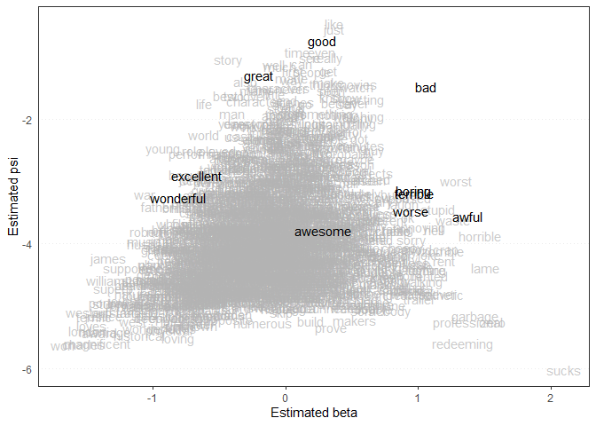

```r
textplot_scale1d(wordfish_model, margin = "features",
                 highlighted = c("good", "great", "awesome", "excellent", "wonderful",
                                 "bad", "worse", "awful", "boring", "terrible"))
```

```r
# Note: Psi explains how common the word is in general, regardless of its role in the latent scal
```

### d) Interpret Documents ($\theta$)

$\theta$ (stored in `wordfish_model$theta`) represents the position of each document on the latent scale, based on the words it contains. It is a continuous variable with positive and negative values (zero being the neutral point of the latent dimension). To compare the results to the observed sentiment values, create a `boxplot()` showing the distribution of `wordfish_model$theta` by the two `sentiment` groups. Does the plot signal a meaningful clustering along the dimension of the latent variable?

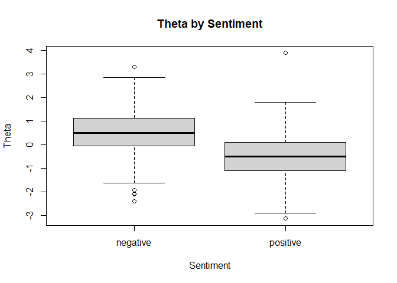

```r
boxplot(wordfish_model$theta ~ movie_ratings_dfm_sample@docvars$sentiment,
        main = "Theta by Sentiment",
        xlab = "Sentiment",
        ylab = "Theta")
```